# Algoritmo de pagerank: explicación

Consideramos la siguiente red, que tiene un callejón sin salida, y dos componentes conexas.

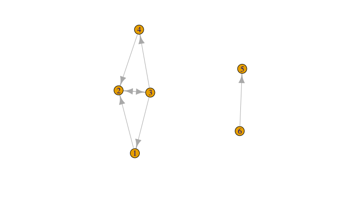

```r
library(tidyverse)
library(tidygraph)
library(ggraph)
red_p <- igraph::graph(c(1,2,3,1,2,3,3,2,3,4,4,2,6,5))
plot(red_p)
```

La matriz de adyacencia es:

```r
A <- igraph::get.adjacency(red_p) %>% as.matrix
A
```

```
     [,1] [,2] [,3] [,4] [,5] [,6]
[1,]    0    1    0    0    0    0
[2,]    0    0    1    0    0    0
[3,]    1    1    0    1    0    0
[4,]    0    1    0    0    0    0
[5,]    0    0    0    0    0    0
[6,]    0    0    0    0    1    0
```

Nótese que hay un renglón de ceros por el callejón sin salida (nodo 5)

### Cálculo teórico de la matriz de pagerank

Normalizando por renglón, obtenemos:

```r
M <- A / apply(A, 1, sum)
M
```

```
          [,1]      [,2] [,3]      [,4] [,5] [,6]
[1,] 0.0000000 1.0000000    0 0.0000000    0    0
[2,] 0.0000000 0.0000000    1 0.0000000    0    0
[3,] 0.3333333 0.3333333    0 0.3333333    0    0
[4,] 0.0000000 1.0000000    0 0.0000000    0    0
[5,]       NaN       NaN  NaN       NaN  NaN  NaN
[6,] 0.0000000 0.0000000    0 0.0000000    1    0
```

Por el callejón sin salida obtenemos un renglon no definido (el 5). Este renglón debe ser de ceros:

```r
M[5, ] <- 0
M
```

```
          [,1]      [,2] [,3]      [,4] [,5] [,6]
[1,] 0.0000000 1.0000000    0 0.0000000    0    0
[2,] 0.0000000 0.0000000    1 0.0000000    0    0
[3,] 0.3333333 0.3333333    0 0.3333333    0    0
[4,] 0.0000000 1.0000000    0 0.0000000    0    0
[5,] 0.0000000 0.0000000    0 0.0000000    0    0
[6,] 0.0000000 0.0000000    0 0.0000000    1    0
```

Y esta es la matriz con la que comenzamos.

La perturbación de pagerank con $\alpha = 0.9$ consiste en:

1. Para los renglones que no son callejón sin salida, poner
   $$0.9 M_1 + (1-0.9)\frac{1}{6}$$
2. Poner saltos de misma probabilidad desde el callejón sin salida a todos los nodos

Para el paso 1 hacemos

```r
M_1 <- 0.9 * M + 0.1/6
M_1
```

```
           [,1]       [,2]       [,3]       [,4]       [,5]       [,6]
[1,] 0.01666667 0.91666667 0.01666667 0.01666667 0.01666667 0.01666667
[2,] 0.01666667 0.01666667 0.91666667 0.01666667 0.01666667 0.01666667
[3,] 0.31666667 0.31666667 0.01666667 0.31666667 0.01666667 0.01666667
[4,] 0.01666667 0.91666667 0.01666667 0.01666667 0.01666667 0.01666667
[5,] 0.01666667 0.01666667 0.01666667 0.01666667 0.01666667 0.01666667
[6,] 0.01666667 0.01666667 0.01666667 0.01666667 0.91666667 0.01666667
```

Todavía no está completa, para el paso 2 hacemos

```r
M_1[5, ] <- 1/6
M_1 %>% round(3)
```

```
      [,1]  [,2]  [,3]  [,4]  [,5]  [,6]
[1,] 0.017 0.917 0.017 0.017 0.017 0.017
[2,] 0.017 0.017 0.917 0.017 0.017 0.017
[3,] 0.317 0.317 0.017 0.317 0.017 0.017
[4,] 0.017 0.917 0.017 0.017 0.017 0.017
[5,] 0.167 0.167 0.167 0.167 0.167 0.167
[6,] 0.017 0.017 0.017 0.017 0.917 0.017
```

Y esta es la matriz $M_1$

Consideremos una iteración del vector $v$

```r
v <- rep(1/6, 6)
t(M_1) %*% v
```

```
           [,1]
[1,] 0.09166667
[2,] 0.39166667
[3,] 0.19166667
[4,] 0.09166667
[5,] 0.19166667
[6,] 0.04166667
```

Esta es la primera iteración de pagerank. Puedes hacer más iteraciones a ver dónde converge:

```r
for(i in 1:20){
  v <- t(M_1) %*% v
}
v
```

```
           [,1]
[1,] 0.12432460
[2,] 0.34778311
[3,] 0.33596859
[4,] 0.12432460
[5,] 0.04428907
[6,] 0.02331003
```

**Observación**: así **no** se calcula pagerank!!! Se calcula como mostramos abajo:

## Algoritmo de pagerank

Vamos a descomponer a $M_1$ en tres partes: una que corresponde a la matriz original, otra a la unión de nodos que no son callejones con el resto de la red, y una correspondiente a callejones sin salida.

La matriz de pagerank la podemos escribir como

```r
# M_1 = A_red + A_salida + A_callejon
A_red <- 0.9 * M
A_salida <- matrix( 0.1 * 1/6, nrow = 6, ncol = 6)
A_salida[5, ] <- 0
A_callejon <- matrix(0, nrow = 6, ncol = 6)
A_callejon[5, ] <- 1/6
```

Tenemos

```r
A_red %>% round(3)
```

```
     [,1] [,2] [,3] [,4] [,5] [,6]
[1,]  0.0  0.9  0.0  0.0  0.0    0
[2,]  0.0  0.0  0.9  0.0  0.0    0
[3,]  0.3  0.3  0.0  0.3  0.0    0
[4,]  0.0  0.9  0.0  0.0  0.0    0
[5,]  0.0  0.0  0.0  0.0  0.0    0
[6,]  0.0  0.0  0.0  0.0  0.9    0
```

```r
A_salida %>% round(3)
```

```
      [,1]  [,2]  [,3]  [,4]  [,5]  [,6]
[1,] 0.017 0.017 0.017 0.017 0.017 0.017
[2,] 0.017 0.017 0.017 0.017 0.017 0.017
[3,] 0.017 0.017 0.017 0.017 0.017 0.017
[4,] 0.017 0.017 0.017 0.017 0.017 0.017
[5,] 0.000 0.000 0.000 0.000 0.000 0.000
[6,] 0.017 0.017 0.017 0.017 0.017 0.017
```

```r
A_callejon %>% round(3)
```

```
      [,1]  [,2]  [,3]  [,4]  [,5]  [,6]
[1,] 0.000 0.000 0.000 0.000 0.000 0.000
[2,] 0.000 0.000 0.000 0.000 0.000 0.000
[3,] 0.000 0.000 0.000 0.000 0.000 0.000
[4,] 0.000 0.000 0.000 0.000 0.000 0.000
[5,] 0.167 0.167 0.167 0.167 0.167 0.167
[6,] 0.000 0.000 0.000 0.000 0.000 0.000
```

Checamos que la suma da la matriz $M$ perturbada de pagerank:

```r
M %>% round(3)
```

```
      [,1]  [,2] [,3]  [,4] [,5] [,6]
[1,] 0.000 1.000    0 0.000    0    0
[2,] 0.000 0.000    1 0.000    0    0
[3,] 0.333 0.333    0 0.333    0    0
[4,] 0.000 1.000    0 0.000    0    0
[5,] 0.000 0.000    0 0.000    0    0
[6,] 0.000 0.000    0 0.000    1    0
```

```r
(A_red + A_salida + A_callejon) %>% round(3)
```

```
      [,1]  [,2]  [,3]  [,4]  [,5]  [,6]
[1,] 0.017 0.917 0.017 0.017 0.017 0.017
[2,] 0.017 0.017 0.917 0.017 0.017 0.017
[3,] 0.317 0.317 0.017 0.317 0.017 0.017
[4,] 0.017 0.917 0.017 0.017 0.017 0.017
[5,] 0.167 0.167 0.167 0.167 0.167 0.167
[6,] 0.017 0.017 0.017 0.017 0.917 0.017
```

Ahora vemos que pasa cuando multiplicamos por un vector:

```r
v <- c(1,2,3,4,5,6) / sum(1:6)
t(A_red) %*% v
```

```
           [,1]
[1,] 0.04285714
[2,] 0.25714286
[3,] 0.08571429
[4,] 0.04285714
[5,] 0.25714286
[6,] 0.00000000
```

```r
t(A_salida) %*% v
```

```
           [,1]
[1,] 0.01269841
[2,] 0.01269841
[3,] 0.01269841
[4,] 0.01269841
[5,] 0.01269841
[6,] 0.01269841
```

```r
t(A_callejon) %*% v
```

```
           [,1]
[1,] 0.03968254
[2,] 0.03968254
[3,] 0.03968254
[4,] 0.03968254
[5,] 0.03968254
[6,] 0.03968254
```

Y obsérvese que el segundo y el tercer vector **son constantes**. ¿Por qué? Examina las multiplicaciones correspondientes. Examina las transpuestas de A_salida y A_callejon.

Examinamos qué pasa cuando hacemos una iteración de pagerank de la manera lenta. La iteración da_

```r
# esta multiplicacion NO la queremos hacer
w <- t(M_1) %*% v
w
```

```
           [,1]
[1,] 0.09523810
[2,] 0.30952381
[3,] 0.13809524
[4,] 0.09523810
[5,] 0.30952381
[6,] 0.05238095
```

```r
sum(w)
```

```
[1] 1
```

El vector resultante siempre suma uno. De manera que podemos hacer:

```r
w_1 = t(A_red) %*% v
w_1
```

```
           [,1]
[1,] 0.04285714
[2,] 0.25714286
[3,] 0.08571429
[4,] 0.04285714
[5,] 0.25714286
[6,] 0.00000000
```

y para saber la constante que debemos sumar es fácil, porque tiene que ser una constante tal que las componentes de $w$ sumen 1:

```r
constante <- (1-sum(w_1))/6
w <- w_1 + constante
w
```

```
           [,1]
[1,] 0.09523810
[2,] 0.30952381
[3,] 0.13809524
[4,] 0.09523810
[5,] 0.30952381
[6,] 0.05238095
```

que es igual a

```r
t(M_1) %*% v
```

```
           [,1]
[1,] 0.09523810
[2,] 0.30952381
[3,] 0.13809524
[4,] 0.09523810
[5,] 0.30952381
[6,] 0.05238095
```